# Modeling AutoBi with tweedie Package

Seth Temple

```r
library(tweedie)
library(statmod)
library(ggplot2)
library(insuranceData)
```

```r
data(AutoBi)
```

Wrangle the AGE column.

```r
AgeFactor <- with(AutoBi, {
  (CLMAGE == "0" | CLMAGE == "1" | CLMAGE == "2" | CLMAGE == "3" | CLMAGE == "4" | CLMAGE == "5" | CLMAGE == "6" | CLMAGE == "7" | CLMAGE == "8" | CLMAGE == "9")*1 + (CLMAGE == "10" | CLMAGE == "11" | CLMAGE == "12" | CLMAGE == "13" | CLMAGE == "14" | CLMAGE == "15" | CLMAGE == "16" | CLMAGE == "17" | CLMAGE == "18" | CLMAGE == "19")*2 + (CLMAGE == "20" | CLMAGE == "21" | CLMAGE == "22" | CLMAGE == "23" | CLMAGE == "24" | CLMAGE == "25" | CLMAGE == "26" | CLMAGE == "27" | CLMAGE == "28" | CLMAGE == "29" | CLMAGE == "30" | CLMAGE == "31" | CLMAGE == "32" | CLMAGE == "33" | CLMAGE == "34" | CLMAGE == "35" | CLMAGE == "36" | CLMAGE == "37" | CLMAGE == "38" | CLMAGE == "39")*3 + (CLMAGE == "40" | CLMAGE == "41" | CLMAGE == "42" | CLMAGE == "43" | CLMAGE == "44" | CLMAGE == "45" | CLMAGE == "46" | CLMAGE == "47" | CLMAGE == "48" | CLMAGE == "49" | CLMAGE == "50" | CLMAGE == "51" | CLMAGE == "52" | CLMAGE == "53" | CLMAGE == "54" | CLMAGE == "55" | CLMAGE == "56" | CLMAGE == "57" | CLMAGE == "58" | CLMAGE == "59")*4 + (CLMAGE == "60" | CLMAGE == "61" | CLMAGE == "62" | CLMAGE == "63" | CLMAGE == "64" | CLMAGE == "65" | CLMAGE == "66" | CLMAGE == "67" | CLMAGE == "68" | CLMAGE == "69" |CLMAGE == "70" | CLMAGE == "71" | CLMAGE == "72" | CLMAGE == "73" | CLMAGE == "74" | CLMAGE == "75" | CLMAGE == "76" | CLMAGE == "77" | CLMAGE == "78" | CLMAGE == "79" | CLMAGE == "80" | CLMAGE == "81" | CLMAGE == "82" | CLMAGE == "83" | CLMAGE == "84" | CLMAGE == "85" | CLMAGE == "86" | CLMAGE == "87" | CLMAGE == "88" | CLMAGE == "89" | CLMAGE == "90" | CLMAGE == "91" | CLMAGE == "92" | CLMAGE == "93" | CLMAGE == "94" | CLMAGE == "95" | CLMAGE == "96" | CLMAGE == "97" | CLMAGE == "98" | CLMAGE == "99")*5
}
)
AutoBi$AGE <- AgeFactor
rm(AgeFactor)
```

Record empties as 0.

```r
AutoBi$CASENUM <- ifelse(is.na(AutoBi$CASENUM), 0, AutoBi$CASENUM)
AutoBi$MARITAL <- ifelse(is.na(AutoBi$MARITAL), 0, AutoBi$MARITAL)
AutoBi$AGE <- ifelse(is.na(AutoBi$AGE), 0, AutoBi$AGE)
AutoBi$ATTORNEY <- ifelse(is.na(AutoBi$ATTORNEY), 0, AutoBi$ATTORNEY)
AutoBi$CLMSEX <- ifelse(is.na(AutoBi$CLMSEX), 0, AutoBi$CLMSEX)
AutoBi$CLMAGE <- ifelse(is.na(AutoBi$CLMAGE), 0, AutoBi$CLMAGE)
AutoBi$CLMINSUR <- ifelse(is.na(AutoBi$CLMINSUR), 0, AutoBi$CLMINSUR)
AutoBi$SEATBELT <- ifelse(is.na(AutoBi$SEATBELT), 0, AutoBi$SEATBELT)
```

Use some p to build a model.

```
---
 This function may take some time to complete;
 Please be patient.  If it fails, try using  method="series"
 rather than the default  method="inversion"
 Another possible reason for failure is the range of p:
 Try a different input for  p.vec
---
1.8 1.9 2 2.1 2.2 2.3 2.4 2.5 2.6 2.7 2.8 2.9 3 3.1 3.2 3.3 3.4 3.5
p = 1.8
* Fitting initial model: Done
* Phi estimation, method:  mle (using optimize):  Done (phi = 2.324067 )
* Computing the log-likelihood (method = interpolation ): Done: L = -3692.952
p = 1.9
* Fitting initial model: Done
* Phi estimation, method:  mle (using optimize):  Done (phi = 2.121427 )
* Computing the log-likelihood (method = interpolation ): Done: L = -3567.304
p = 2
* Fitting initial model: Done
* Phi estimation, method:  mle (using optimize):  Done (phi = 1.941044 )
* Computing the log-likelihood (method = interpolation ): Done: L = -3469.226
p = 2.1
* Fitting initial model: Done
* Phi estimation, method:  mle (using optimize):  Done (phi = 1.788113 )
* Computing the log-likelihood (method = interpolation ): Done: L = -3392.899
p = 2.2
* Fitting initial model: Done
* Phi estimation, method:  mle (using optimize):  Done (phi = 1.664594 )
* Computing the log-likelihood (method = interpolation ): Done: L = -3335.065
p = 2.3
* Fitting initial model: Done
* Phi estimation, method:  mle (using optimize):  Done (phi = 1.570862 )
* Computing the log-likelihood (method = interpolation ): Done: L = -3293.987
p = 2.4
* Fitting initial model: Done
* Phi estimation, method:  mle (using optimize):  Done (phi = 1.507034 )
* Computing the log-likelihood (method = interpolation ): Done: L = -3268.873
p = 2.5
* Fitting initial model: Done
* Phi estimation, method:  mle (using optimize):  Done (phi = 1.473818 )
* Computing the log-likelihood (method = interpolation ): Done: L = -3259.549
```

[output cut: 31 more lines]

```
* Computing the log-likelihood (method = interpolation ): Done: L = -3797.479
p = 3.4
* Fitting initial model: Done
* Phi estimation, method:  mle (using optimize):  Done (phi = 4.400371 )
* Computing the log-likelihood (method = interpolation ): Done: L = -3939.307
p = 3.5
* Fitting initial model: Done
* Phi estimation, method:  mle (using optimize):  Done (phi = 5.895995 )
* Computing the log-likelihood (method = interpolation ): Done: L = -4092.859
. ---
* Smoothing:  Done
 Estimating phi:   Done
ML Estimates:   p = 2.493878  with phi= 1.474957  giving L= -3259.663
 ---
* Finding confidence interval: Done
```

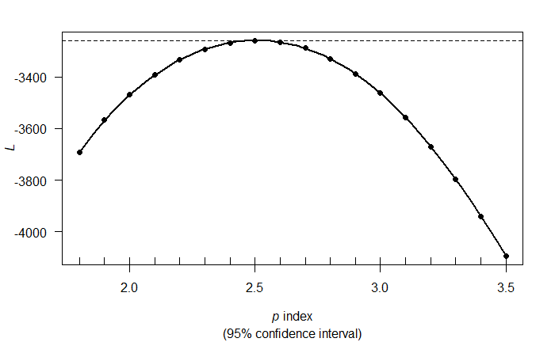

```r
tweedie.profile(LOSS~1, data=AutoBi,
                do.smooth=TRUE, do.plot=TRUE, verbose=2,
                method="interpolation",
                p.vec=seq(1.8,3.5,.1),
                link.power=1)
```

```r
disp <- 1.473818
disp_gamma <- 1.941044
```

```r
m0 <- glm(LOSS~1, data=AutoBi,
          family=tweedie(var.power=2.5, link.power=0))
AICtweedie(m0, k=2, dispersion=disp)
```

```
[1] 6521.098
```

Add features to the model that decrease AIC.

```r
m1 <- glm(LOSS~1+as.factor(ATTORNEY), data=AutoBi,
          family=tweedie(var.power=2.5, link.power=0))
summary(m1)
```

```
Call:
glm(formula = LOSS ~ 1 + as.factor(ATTORNEY), family = tweedie(var.power = 2.5,
    link.power = 0), data = AutoBi)

Deviance Residuals:
    Min       1Q   Median       3Q      Max
-5.8979  -1.0478  -0.5528  -0.0428   6.6908

Coefficients:
                     Estimate Std. Error t value Pr(>|t|)
(Intercept)            2.2888     0.1526  14.996   <2e-16 ***
as.factor(ATTORNEY)2  -1.6657     0.1841  -9.048   <2e-16 ***
---
Signif. codes:  0 ‘***’ 0.001 ‘**’ 0.01 ‘*’ 0.05 ‘.’ 0.1 ‘ ’ 1

(Dispersion parameter for Tweedie family taken to be 5.080942)

    Null deviance: 2172.3  on 1339  degrees of freedom
Residual deviance: 1776.0  on 1338  degrees of freedom
AIC: NA

Number of Fisher Scoring iterations: 10
```

```r
AICtweedie(m1, k=2, dispersion=disp)
```

```
[1] 6254.254
```

Yes.

```r
m2 <- glm(LOSS~1+as.factor(ATTORNEY)+as.factor(AGE), data=AutoBi,
          family=tweedie(var.power=2.5, link.power=0))
summary(m2)
```

```
Call:
glm(formula = LOSS ~ 1 + as.factor(ATTORNEY) + as.factor(AGE),
    family = tweedie(var.power = 2.5, link.power = 0), data = AutoBi)

Deviance Residuals:
    Min       1Q   Median       3Q      Max
-5.9039  -0.9704  -0.5287  -0.0269   5.4706

Coefficients:
                     Estimate Std. Error t value Pr(>|t|)
(Intercept)            2.5521     0.2168  11.769  < 2e-16 ***
as.factor(ATTORNEY)2  -1.5469     0.1406 -11.006  < 2e-16 ***
as.factor(AGE)1       -1.6154     0.2797  -5.775 9.59e-09 ***
as.factor(AGE)2       -0.7579     0.2421  -3.131  0.00178 **
as.factor(AGE)3       -0.3336     0.2217  -1.505  0.13255
as.factor(AGE)4       -0.1273     0.2432  -0.524  0.60062
as.factor(AGE)5       -0.7466     0.3108  -2.402  0.01643 *
---
Signif. codes:  0 ‘***’ 0.001 ‘**’ 0.01 ‘*’ 0.05 ‘.’ 0.1 ‘ ’ 1

(Dispersion parameter for Tweedie family taken to be 3.179643)

    Null deviance: 2172.3  on 1339  degrees of freedom
Residual deviance: 1676.2  on 1333  degrees of freedom
AIC: NA

Number of Fisher Scoring iterations: 17
```

```r
AICtweedie(m2, k=2, dispersion=disp)
```

```
[1] 6196.499
```

Yes.

```r
m3 <- glm(LOSS~1+as.factor(ATTORNEY)+as.factor(AGE)+as.factor(SEATBELT), data=AutoBi,
          family=tweedie(var.power=2.5, link.power=0))
summary(m3)
```

```
Call:
glm(formula = LOSS ~ 1 + as.factor(ATTORNEY) + as.factor(AGE) +
    as.factor(SEATBELT), family = tweedie(var.power = 2.5, link.power = 0),
    data = AutoBi)

Deviance Residuals:
    Min       1Q   Median       3Q      Max
-5.9036  -0.9694  -0.5227  -0.0182   5.5783

Coefficients:
                     Estimate Std. Error t value Pr(>|t|)
(Intercept)            1.8465     0.3565   5.179 2.57e-07 ***
as.factor(ATTORNEY)2  -1.5126     0.1407 -10.748  < 2e-16 ***
as.factor(AGE)1       -1.6185     0.2792  -5.797 8.40e-09 ***
as.factor(AGE)2       -0.7487     0.2429  -3.082   0.0021 **
as.factor(AGE)3       -0.3446     0.2213  -1.557   0.1197
as.factor(AGE)4       -0.1092     0.2438  -0.448   0.6542
as.factor(AGE)5       -0.7112     0.3136  -2.268   0.0235 *
as.factor(SEATBELT)1   0.6802     0.3097   2.196   0.0283 *
as.factor(SEATBELT)2   1.4677     0.7592   1.933   0.0534 .
---
Signif. codes:  0 ‘***’ 0.001 ‘**’ 0.01 ‘*’ 0.05 ‘.’ 0.1 ‘ ’ 1

(Dispersion parameter for Tweedie family taken to be 3.224027)

    Null deviance: 2172.3  on 1339  degrees of freedom
Residual deviance: 1658.6  on 1331  degrees of freedom
AIC: NA

Number of Fisher Scoring iterations: 16
```

```r
AICtweedie(m3, k=2, dispersion=disp)
```

```
[1] 6188.604
```

Yes.

```r
m4 <- glm(LOSS~1+as.factor(ATTORNEY)+as.factor(AGE)+as.factor(SEATBELT)
          +as.factor(CLMINSUR),
          data=AutoBi,
          family=tweedie(var.power=2.5, link.power=0))
summary(m4)
```

```
Call:
glm(formula = LOSS ~ 1 + as.factor(ATTORNEY) + as.factor(AGE) +
    as.factor(SEATBELT) + as.factor(CLMINSUR), family = tweedie(var.power = 2.5,
    link.power = 0), data = AutoBi)

Deviance Residuals:
    Min       1Q   Median       3Q      Max
-5.9073  -0.9643  -0.5178  -0.0249   5.5529

Coefficients:
                     Estimate Std. Error t value Pr(>|t|)
(Intercept)           1.91344    0.41244   4.639 3.84e-06 ***
as.factor(ATTORNEY)2 -1.50638    0.13993 -10.765  < 2e-16 ***
as.factor(AGE)1      -1.63211    0.27702  -5.892 4.84e-09 ***
as.factor(AGE)2      -0.75476    0.24078  -3.135  0.00176 **
as.factor(AGE)3      -0.32610    0.22006  -1.482  0.13861
as.factor(AGE)4      -0.08785    0.24250  -0.362  0.71719
as.factor(AGE)5      -0.71741    0.31092  -2.307  0.02119 *
as.factor(SEATBELT)1  0.83200    0.37962   2.192  0.02858 *
as.factor(SEATBELT)2  1.59382    0.78558   2.029  0.04267 *
as.factor(CLMINSUR)1 -0.45439    0.49971  -0.909  0.36335
as.factor(CLMINSUR)2 -0.21281    0.45956  -0.463  0.64339
---
Signif. codes:  0 ‘***’ 0.001 ‘**’ 0.01 ‘*’ 0.05 ‘.’ 0.1 ‘ ’ 1

(Dispersion parameter for Tweedie family taken to be 3.174805)

    Null deviance: 2172.3  on 1339  degrees of freedom
Residual deviance: 1655.1  on 1329  degrees of freedom
AIC: NA

Number of Fisher Scoring iterations: 16
```

```r
AICtweedie(m4, k=2, dispersion=disp)
```

```
[1] 6190.164
```

No. Last two features CLMSEX and MARITAL cause an error in the glm.fit algorithm.

```
---
 This function may take some time to complete;
 Please be patient.  If it fails, try using  method="series"
 rather than the default  method="inversion"
 Another possible reason for failure is the range of p:
 Try a different input for  p.vec
---
1.8 1.9 2 2.1 2.2 2.3 2.4 2.5 2.6 2.7
p = 1.8
* Fitting initial model: Done
* Phi estimation, method:  mle (using optimize):  Done (phi = 1.64816 )
* Computing the log-likelihood (method = interpolation ): Done: L = -3310.219
p = 1.9
* Fitting initial model: Done
* Phi estimation, method:  mle (using optimize):  Done (phi = 1.492658 )
* Computing the log-likelihood (method = interpolation ): Done: L = -3209.874
p = 2
* Fitting initial model: Done
* Phi estimation, method:  mle (using optimize):  Done (phi = 1.365224 )
* Computing the log-likelihood (method = interpolation ): Done: L = -3136.307
p = 2.1
* Fitting initial model: Done
* Phi estimation, method:  mle (using optimize):  Done (phi = 1.26659 )
* Computing the log-likelihood (method = interpolation ): Done: L = -3084.998
p = 2.2
* Fitting initial model: Done
* Phi estimation, method:  mle (using optimize):  Done (phi = 1.195569 )
* Computing the log-likelihood (method = interpolation ): Done: L = -3053.282
p = 2.3
* Fitting initial model: Done
* Phi estimation, method:  mle (using optimize):  Done (phi = 1.150814 )
* Computing the log-likelihood (method = interpolation ): Done: L = -3039.502
p = 2.4
* Fitting initial model: Done
* Phi estimation, method:  mle (using optimize):  Done (phi = 1.131621 )
* Computing the log-likelihood (method = interpolation ): Done: L = -3042.598
p = 2.5
* Fitting initial model: Done
* Phi estimation, method:  mle (using optimize):  Done (phi = 1.13846 )
* Computing the log-likelihood (method = interpolation ): Done: L = -3061.9
p = 2.6
* Fitting initial model: Done
* Phi estimation, method:  mle (using optimize):  Done (phi = 1.173548 )
* Computing the log-likelihood (method = interpolation ): Done: L = -3097.01
p = 2.7
* Fitting initial model: Done
* Phi estimation, method:  mle (using optimize):  Done (phi = 1.241376 )
* Computing the log-likelihood (method = interpolation ): Done: L = -3147.726
. ---
* Smoothing:  Done
 Estimating phi:   Done
ML Estimates:   p = 2.332653  with phi= 1.141751  giving L= -3038.696
 ---
* Finding confidence interval: Done
```

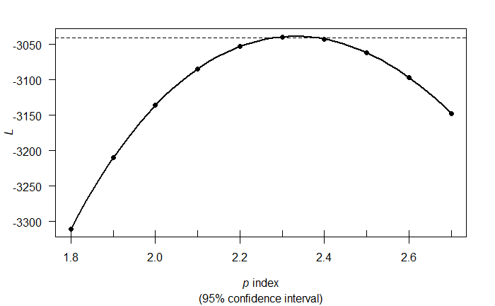

```r
out <- tweedie.profile(LOSS~1+as.factor(ATTORNEY)+as.factor(SEATBELT)+as.factor(AGE),
                       data=AutoBi,
                       do.plot=TRUE, do.smooth=TRUE, verbose=2, link.power=0,
                       method="interpolation",
                       p.vec=seq(1.8,2.7,.1))
```

```r
pmax <- out$p.max
phimax <- out$phi.max
phigamma <- 1.365224
phi2.5 <- 1.13846
```

```r
gamma_model <- glm(LOSS~1+as.factor(ATTORNEY)+as.factor(SEATBELT)+as.factor(AGE),
                   data=AutoBi,
                   family=tweedie(var.power=2, link.power=0))
summary(gamma_model)
```

```
Call:
glm(formula = LOSS ~ 1 + as.factor(ATTORNEY) + as.factor(SEATBELT) +
    as.factor(AGE), family = tweedie(var.power = 2, link.power = 0),
    data = AutoBi)

Deviance Residuals:
    Min       1Q   Median       3Q      Max
-3.1460  -1.2192  -0.7082  -0.0240  11.4635

Coefficients:
                     Estimate Std. Error t value Pr(>|t|)
(Intercept)            1.9808     0.4261   4.649 3.67e-06 ***
as.factor(ATTORNEY)2  -1.5479     0.1468 -10.543  < 2e-16 ***
as.factor(SEATBELT)1   0.7302     0.3936   1.855 0.063766 .
as.factor(SEATBELT)2   1.6254     0.6896   2.357 0.018569 *
as.factor(AGE)1       -1.8112     0.3555  -5.095 3.99e-07 ***
as.factor(AGE)2       -0.9800     0.2670  -3.670 0.000252 ***
as.factor(AGE)3       -0.5154     0.2306  -2.235 0.025603 *
as.factor(AGE)4       -0.2795     0.2487  -1.124 0.261272
as.factor(AGE)5       -0.9211     0.3567  -2.583 0.009915 **
---
Signif. codes:  0 ‘***’ 0.001 ‘**’ 0.01 ‘*’ 0.05 ‘.’ 0.1 ‘ ’ 1

(Dispersion parameter for Tweedie family taken to be 7.127291)

    Null deviance: 3289.0  on 1339  degrees of freedom
Residual deviance: 2197.3  on 1331  degrees of freedom
AIC: NA

Number of Fisher Scoring iterations: 10
```

```r
AICtweedie(gamma_model, k=2, dispersion=phigamma)
```

```
[1] 6290.613
```

```r
mid_model <- glm(LOSS~1+as.factor(ATTORNEY)+as.factor(SEATBELT)+as.factor(AGE),
                   data=AutoBi,
                   family=tweedie(var.power=2.5, link.power=0))
summary(mid_model)
```

```
Call:
glm(formula = LOSS ~ 1 + as.factor(ATTORNEY) + as.factor(SEATBELT) +
    as.factor(AGE), family = tweedie(var.power = 2.5, link.power = 0),
    data = AutoBi)

Deviance Residuals:
    Min       1Q   Median       3Q      Max
-5.9036  -0.9694  -0.5227  -0.0182   5.5783

Coefficients:
                     Estimate Std. Error t value Pr(>|t|)
(Intercept)            1.8465     0.3565   5.179 2.57e-07 ***
as.factor(ATTORNEY)2  -1.5126     0.1407 -10.748  < 2e-16 ***
as.factor(SEATBELT)1   0.6802     0.3097   2.196   0.0283 *
as.factor(SEATBELT)2   1.4677     0.7592   1.933   0.0534 .
as.factor(AGE)1       -1.6185     0.2792  -5.797 8.40e-09 ***
as.factor(AGE)2       -0.7487     0.2429  -3.082   0.0021 **
as.factor(AGE)3       -0.3446     0.2213  -1.557   0.1197
as.factor(AGE)4       -0.1092     0.2438  -0.448   0.6542
as.factor(AGE)5       -0.7112     0.3136  -2.268   0.0235 *
---
Signif. codes:  0 ‘***’ 0.001 ‘**’ 0.01 ‘*’ 0.05 ‘.’ 0.1 ‘ ’ 1

(Dispersion parameter for Tweedie family taken to be 3.224027)

    Null deviance: 2172.3  on 1339  degrees of freedom
Residual deviance: 1658.6  on 1331  degrees of freedom
AIC: NA

Number of Fisher Scoring iterations: 16
```

```r
AICtweedie(mid_model, k=2, dispersion=phi2.5)
```

```
[1] 6141.8
```

```r
max_model <- glm(LOSS~1+as.factor(ATTORNEY)+as.factor(SEATBELT)+as.factor(AGE),
                   data=AutoBi,
                   family=tweedie(var.power=pmax, link.power=0))
summary(max_model)
```

```
Call:
glm(formula = LOSS ~ 1 + as.factor(ATTORNEY) + as.factor(SEATBELT) +
    as.factor(AGE), family = tweedie(var.power = pmax, link.power = 0),
    data = AutoBi)

Deviance Residuals:
    Min       1Q   Median       3Q      Max
-4.6337  -1.0435  -0.5797  -0.0210   6.9957

Coefficients:
                     Estimate Std. Error t value Pr(>|t|)
(Intercept)            1.8937     0.3766   5.029 5.60e-07 ***
as.factor(ATTORNEY)2  -1.5230     0.1407 -10.823  < 2e-16 ***
as.factor(SEATBELT)1   0.6926     0.3341   2.073  0.03837 *
as.factor(SEATBELT)2   1.5193     0.7317   2.076  0.03805 *
as.factor(AGE)1       -1.6807     0.3007  -5.590 2.76e-08 ***
as.factor(AGE)2       -0.8212     0.2506  -3.277  0.00108 **
as.factor(AGE)3       -0.3993     0.2251  -1.774  0.07633 .
as.factor(AGE)4       -0.1639     0.2460  -0.666  0.50533
as.factor(AGE)5       -0.7783     0.3266  -2.383  0.01731 *
---
Signif. codes:  0 ‘***’ 0.001 ‘**’ 0.01 ‘*’ 0.05 ‘.’ 0.1 ‘ ’ 1

(Dispersion parameter for Tweedie family taken to be 4.118519)

    Null deviance: 2364.0  on 1339  degrees of freedom
Residual deviance: 1708.9  on 1331  degrees of freedom
AIC: NA

Number of Fisher Scoring iterations: 14
```

```r
AICtweedie(max_model, k=2, dispersion=phimax)
```

```
[1] 6095.393
```

We achieved the lowest AIC with the MLE estimate for p and phi. Notice that the coefficients haven’t changed much between the models. Let’s assess how this changes the fitted loss costs.

There appears to be a trend here. As the model gets closer to inverse-Gaussian, the fitted values get smaller. Compared to the gamma, the inverse-Gaussian has a sharper peak and a wider tail. This behavior may explain this trend.

```r
sum(max_model$fitted.values)/sum(AutoBi$LOSS)
```

```
[1] 0.936587
```

```r
sum(mid_model$fitted.values)/sum(AutoBi$LOSS)
```

```
[1] 0.9256175
```

```r
sum(gamma_model$fitted.values)/sum(AutoBi$LOSS)
```

```
[1] 0.9587962
```

Our model with the MLE estimate for p predicts $177K less in losses than the gamma model.

```r
percent <- sum(gamma_model$fitted.values)/sum(AutoBi$LOSS) - sum(max_model$fitted.values)/sum(AutoBi$LOSS)
sum(AutoBi$LOSS)*percent*1000
```

```
[1] 177177.1
```

The total losses for the insurer are about 8 million. 1340 observations is a reasonably-sized severity dataset.

```r
sum(AutoBi$LOSS)*1000
```

```
[1] 7977638
```

Now, let’s look at our results with training and testing sets.

```r
smp_size <- floor(0.75 * nrow(AutoBi))
set.seed(100395)
train_ind <- sample(seq_len(nrow(AutoBi)), size = smp_size)
train_autobi <- AutoBi[train_ind, ]
test_autobi <- AutoBi[-train_ind, ]
```

```
---
 This function may take some time to complete;
 Please be patient.  If it fails, try using  method="series"
 rather than the default  method="inversion"
 Another possible reason for failure is the range of p:
 Try a different input for  p.vec
---
1.8 1.9 2 2.1 2.2 2.3 2.4 2.5 2.6 2.7
p = 1.8
* Fitting initial model: Done
* Phi estimation, method:  mle (using optimize):  Done (phi = 1.51155 )
* Computing the log-likelihood (method = interpolation ): Done: L = -2402.592
p = 1.9
* Fitting initial model: Done
* Phi estimation, method:  mle (using optimize):  Done (phi = 1.387912 )
* Computing the log-likelihood (method = interpolation ): Done: L = -2341.389
p = 2
* Fitting initial model: Done
* Phi estimation, method:  mle (using optimize):  Done (phi = 1.28493 )
* Computing the log-likelihood (method = interpolation ): Done: L = -2296.623
p = 2.1
* Fitting initial model: Done
* Phi estimation, method:  mle (using optimize):  Done (phi = 1.204371 )
* Computing the log-likelihood (method = interpolation ): Done: L = -2265.814
p = 2.2
* Fitting initial model: Done
* Phi estimation, method:  mle (using optimize):  Done (phi = 1.146102 )
* Computing the log-likelihood (method = interpolation ): Done: L = -2247.5
p = 2.3
* Fitting initial model: Done
* Phi estimation, method:  mle (using optimize):  Done (phi = 1.109689 )
* Computing the log-likelihood (method = interpolation ): Done: L = -2240.765
p = 2.4
* Fitting initial model: Done
* Phi estimation, method:  mle (using optimize):  Done (phi = 1.094977 )
* Computing the log-likelihood (method = interpolation ): Done: L = -2245.01
p = 2.5
* Fitting initial model: Done
* Phi estimation, method:  mle (using optimize):  Done (phi = 1.102682 )
* Computing the log-likelihood (method = interpolation ): Done: L = -2259.841
p = 2.6
* Fitting initial model: Done
* Phi estimation, method:  mle (using optimize):  Done (phi = 1.13473 )
* Computing the log-likelihood (method = interpolation ): Done: L = -2285.014
p = 2.7
* Fitting initial model: Done
* Phi estimation, method:  mle (using optimize):  Done (phi = 1.194822 )
* Computing the log-likelihood (method = interpolation ): Done: L = -2320.398
. ---
* Smoothing:  Done
 Estimating phi:   Done
ML Estimates:   p = 2.314286  with phi= 1.106252  giving L= -2240.71
 ---
* Finding confidence interval: Done
```

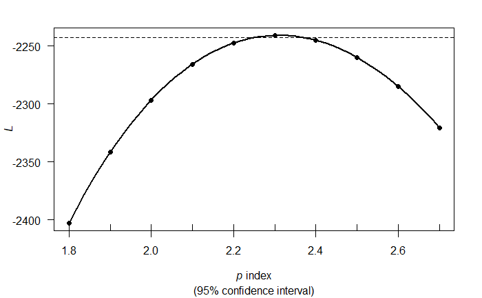

```r
Out <- tweedie.profile(LOSS~1+as.factor(ATTORNEY)+as.factor(SEATBELT)+as.factor(AGE),
                       data=train_autobi,
                       do.plot=TRUE, do.smooth=TRUE, verbose=2, link.power=0,
                       method="interpolation",
                       p.vec=seq(1.8,2.7,.1))
```

```r
PMAX <- Out$p.max
PHIMAX <- Out$phi.max
PhiGa <- 1.28493
```

```r
GAMMA_MODEL <- glm(LOSS~1+as.factor(ATTORNEY)+as.factor(SEATBELT)+as.factor(AGE),
                   data=train_autobi,
                   family=tweedie(var.power=2,link.power=0))
summary(GAMMA_MODEL)
```

```
Call:
glm(formula = LOSS ~ 1 + as.factor(ATTORNEY) + as.factor(SEATBELT) +
    as.factor(AGE), family = tweedie(var.power = 2, link.power = 0),
    data = train_autobi)

Deviance Residuals:
    Min       1Q   Median       3Q      Max
-3.1525  -1.1871  -0.6722  -0.0083   7.8103

Coefficients:
                     Estimate Std. Error t value Pr(>|t|)
(Intercept)           1.83819    0.41792   4.398 1.21e-05 ***
as.factor(ATTORNEY)2 -1.47716    0.13495 -10.946  < 2e-16 ***
as.factor(SEATBELT)1  0.48871    0.38200   1.279  0.20108
as.factor(SEATBELT)2  1.40612    0.65279   2.154  0.03148 *
as.factor(AGE)1      -1.39878    0.31371  -4.459 9.18e-06 ***
as.factor(AGE)2      -0.65441    0.25301  -2.586  0.00984 **
as.factor(AGE)3      -0.18135    0.21385  -0.848  0.39663
as.factor(AGE)4      -0.06688    0.22824  -0.293  0.76958
as.factor(AGE)5      -0.62062    0.32677  -1.899  0.05782 .
---
Signif. codes:  0 ‘***’ 0.001 ‘**’ 0.01 ‘*’ 0.05 ‘.’ 0.1 ‘ ’ 1

(Dispersion parameter for Tweedie family taken to be 4.511287)

    Null deviance: 2199.8  on 1004  degrees of freedom
Residual deviance: 1538.5  on  996  degrees of freedom
AIC: NA

Number of Fisher Scoring iterations: 8
```

```r
MAX_MODEL <- glm(LOSS~1+as.factor(ATTORNEY)+as.factor(SEATBELT)+as.factor(AGE),
                   data=train_autobi,
                   family=tweedie(var.power=PMAX,link.power=0))
summary(MAX_MODEL)
```

```
Call:
glm(formula = LOSS ~ 1 + as.factor(ATTORNEY) + as.factor(SEATBELT) +
    as.factor(AGE), family = tweedie(var.power = PMAX, link.power = 0),
    data = train_autobi)

Deviance Residuals:
    Min       1Q   Median       3Q      Max
-4.5218  -1.0329  -0.5539  -0.0083   6.1273

Coefficients:
                     Estimate Std. Error t value Pr(>|t|)
(Intercept)           1.87137    0.38716   4.834 1.55e-06 ***
as.factor(ATTORNEY)2 -1.47569    0.13235 -11.150  < 2e-16 ***
as.factor(SEATBELT)1  0.44720    0.34446   1.298   0.1945
as.factor(SEATBELT)2  1.31888    0.72824   1.811   0.0704 .
as.factor(AGE)1      -1.40339    0.27604  -5.084 4.42e-07 ***
as.factor(AGE)2      -0.62325    0.24242  -2.571   0.0103 *
as.factor(AGE)3      -0.17209    0.21193  -0.812   0.4170
as.factor(AGE)4      -0.06661    0.22769  -0.293   0.7699
as.factor(AGE)5      -0.63440    0.30540  -2.077   0.0380 *
---
Signif. codes:  0 ‘***’ 0.001 ‘**’ 0.01 ‘*’ 0.05 ‘.’ 0.1 ‘ ’ 1

(Dispersion parameter for Tweedie family taken to be 2.881791)

    Null deviance: 1674.3  on 1004  degrees of freedom
Residual deviance: 1242.3  on  996  degrees of freedom
AIC: NA

Number of Fisher Scoring iterations: 11
```

```r
predict(MAX_MODEL, test_autobi)[1:20]
```

```
        7         9        22        23        33        44        53        56
1.6953203 0.2084823 0.6707993 2.1464860 0.2196336 0.7762743 0.8428851 2.1464860
       57        60        69        72        83        88        89        91
0.8428851 0.6707993 0.6707993 1.6841690 2.3185718 0.6707993 2.1464860 0.8428851
       93        94        95       104
0.2196336 2.1464860 2.2519610 2.3185718
```

```r
predict(GAMMA_MODEL, test_autobi)[1:20]
```

```
        7         9        22        23        33        44        53        56
1.6724895 0.2291226 0.6683949 2.1455502 0.1953341 0.7828669 0.8497443 2.1455502
       57        60        69        72        83        88        89        91
0.8497443 0.6683949 0.6683949 1.7062780 2.3268997 0.6683949 2.1455502 0.8497443
       93        94        95       104
0.1953341 2.1455502 2.2600223 2.3268997
```

```r
test_autobi$LOSS[1:20]
```

```
 [1]  3.538  0.874  0.230 26.262  0.603 23.201  0.497 33.633  0.305  0.987  1.320
[12]  2.600  9.730  0.250  4.227  0.800  1.860 13.028  2.467  2.433
```

```r
sum(abs(exp(predict(MAX_MODEL, test_autobi))-test_autobi$LOSS))
```

```
[1] 2669.487
```

```r
sum(abs(exp(predict(GAMMA_MODEL, test_autobi))-test_autobi$LOSS))
```

```
[1] 2669.282
```

```r
sum(exp(predict(MAX_MODEL, test_autobi)))/sum(test_autobi$LOSS)
```

```
[1] 0.5717042
```

```r
sum(exp(predict(GAMMA_MODEL, test_autobi)))/sum(test_autobi$LOSS)
```

```
[1] 0.5724093
```

Also, both these models suck. They predict only 57% of the cost of the losses. I suspect we need more features in our model.

Conclude with some visualization.

```r
visuals.frame <- data.frame(gammas=exp(predict(GAMMA_MODEL, test_autobi)),
                            maxs=exp(predict(MAX_MODEL, test_autobi)),
                            losses=test_autobi$LOSS)
```

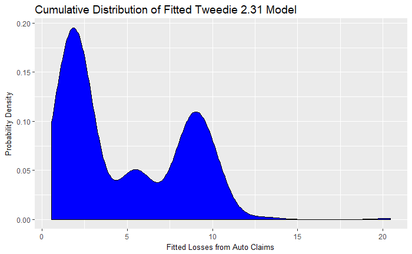

```r
p1 <- ggplot(data=visuals.frame, aes(x=maxs))
p1 + geom_density(size=.5, colour="black", fill="blue") +
  ggtitle("Cumulative Distribution of Fitted Tweedie 2.31 Model") +
  ylab("Probability Density") +
  xlab("Fitted Losses from Auto Claims") +
  theme(axis.title.x=element_text(size=10, family="sans"),
        axis.title.y=element_text(size=10, family="sans"),
        plot.title=element_text(size=14, family="sans"))
```

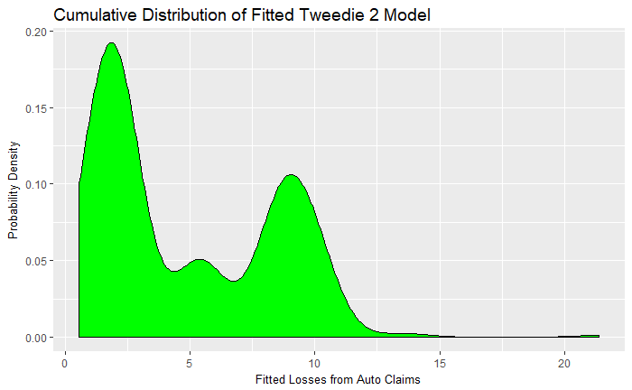

```r
p2 <- ggplot(data=visuals.frame, aes(x=gammas))
p2 + geom_density(size=.5, colour="black", fill="green") +
  ggtitle("Cumulative Distribution of Fitted Tweedie 2 Model") +
  ylab("Probability Density") +
  xlab("Fitted Losses from Auto Claims") +
  theme(axis.title.x=element_text(size=10, family="sans"),
        axis.title.y=element_text(size=10, family="sans"),
        plot.title=element_text(size=14, family="sans"))
```

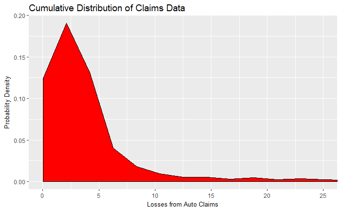

```r
p3 <- ggplot(data=visuals.frame, aes(x=losses))
p3 + geom_density(size=.5, colour="black", fill="red") +
  coord_cartesian(xlim=c(0,25)) +
  ggtitle("Cumulative Distribution of Claims Data") +
  ylab("Probability Density") +
  xlab("Losses from Auto Claims") +
  theme(axis.title.x=element_text(size=10, family="sans"),
        axis.title.y=element_text(size=10, family="sans"),
        plot.title=element_text(size=14, family="sans"))
```

The End. Estimating the Tweedie power didn’t help much. We need more explanatory variables. Check out the LM Home Fire dataset.